# Supplement: Simulated example for fitting Quince model to growth data using hidden Markov model

Tuan Anh Bui<sup>1,2</sup>, Klaas Sys<sup>2</sup>, Jochen Depestele<sup>2</sup>, Marleen De Troch<sup>1</sup>, Karen Bekaert<sup>2</sup>, Jan Jaap Poos<sup>3,4</sup>** <sup>1</sup> Ghent University, Department of Biology, Marine Biology, Krijgslaan 281/S8, Ghent, Belgium <sup>2</sup> Flanders Research Institute for Agriculture, Fisheries and Food (ILVO), Ostend, Belgium <sup>3</sup> Aquaculture and Fisheries Group, Wageningen University and Research, Wageningen, The Netherlands <sup>4</sup> Wageningen Marine Research, Wageningen University and Research, IJmuiden, The Netherlands

2025-04-03

This file contains example code to develop the hidden Markov model - Quince model (HMM-Quince model), to simulate individual growth data, and to fit the model to the data to estimate age at maturity and other life-history traits.

First we load the required libraries and create some functions to be used later.

```r
# load required libraries
library(tidyverse)     # transform data
library(TMB)           # develop and fit model
library(boot)          # get logit function
library(data.table)    # transform data

# functions
# constrain value (-1,1)
itrans <- function(x)(2/(1 + exp(-2*x))-1)

# reverse itrans
itrans_rev <- function(x)(log(2/(x+1)-1)/(-2))

# transform optimisation outputs
transpar <- function(opt){

  itrans <- function(x)(2/(1 + exp(-2*x))-1)

  par_names <- names(opt$par)
  pars <- opt$par
  for(i in 1:length(pars)){
    if(grepl("log", par_names[i]) & !grepl("logit", par_names[i])){
      pars[i] <- exp(pars[i])
      par_names[i] <- unlist(strsplit(par_names[i],"_"))[2]
    }
    if(grepl("logit", par_names[i])){
      pars[i] <- boot::inv.logit(pars[i])
      par_names[i] <- unlist(strsplit(par_names[i],"_"))[2]
    }
    if(grepl("trans", par_names[i])){
      pars[i] <- itrans(pars[i])
      par_names[i] <- unlist(strsplit(par_names[i],"_"))[2]
    }
  }
  names(pars) <- par_names
  pars
}
```

# 1. HMM-Quince model development

The HMM-Quince model is developed in C++ in order to be fitted using TMB package. The development of the model is specified below.

```r
"
#include <TMB.hpp>

// helper functions for NA handling
template<class Type>
bool isNA(Type x){
  return R_IsNA(asDouble(x));
}

template<class Type>
bool isNAINT(int x){
  return NA_INTEGER==x;
}

template <class Type>
Type itrans(Type x){ // scaled ilogit
  return Type(2)/(Type(1) + exp(-Type(2) * x)) - Type(1);
}


// function to transform initial state vector
// n-1 parameters required for n states (sum == 1)
template <class Type>
vector<Type> delta_transform(vector<Type> delta_in)
{
  vector<Type> res_unscaled(delta_in.size()+1);
  res_unscaled(0) = 1;
  for(int i = 1; i<res_unscaled.size();i++){
    res_unscaled(i) = exp(delta_in(i-1));
  }
  return res_unscaled/res_unscaled.sum();
}

template<class Type>
Type objective_function<Type>::operator() ()
{
  /// I. DATA & PARAMETER SECTION ///

  // 1. global variables
  DATA_INTEGER(n_states);                       // number of states
  DATA_IVECTOR(growth_first_idx);               // first index of each growth trajectory in the data

  // 2. state transition model
  // linear covariates
  DATA_MATRIX(beta_linear_covs);                // Intercept and linear covariate for the transition probability matrix

  // 3. covariates/observations & indexes
  // linear effects
  DATA_VECTOR(age);                               // covariates in the growth models
  // the observations
  DATA_MATRIX(len);                               // vector with length-at-age observations
  //DATA_IVECTOR(keyVar);                         // vector that allows to define the variance parameter by state
  DATA_IVECTOR(id);                               // vector fish id

  // 4. initial state parameters
  //PARAMETER_VECTOR(log_delta);                  // initial state probability parameters

  // 5. transition matrix parameters
  PARAMETER_MATRIX(log_beta_linear_pars);          // parameters of linear covariates that govern the state transition probablities

  // 6. parameters of the Quince growth model
  PARAMETER(v0);             // size at age 0
  PARAMETER(log_h);          // potential annual growth rate, h > 0
  PARAMETER(logit_alpha);    // proportion of the growing season in the first adult year devoted to growth (0 < alpha < 1)
  PARAMETER(logit_chi);      // indicator of the annual decrease rate of alpha (0 < chi < 1)
  // Tmat is defined below


  // 7. observation variance
  PARAMETER(log_prec);        // precision
  PARAMETER(log_sd_h);        // standard deviation h
  PARAMETER(log_sd_tmat);     // standard deviation Tmat

  PARAMETER_VECTOR(trans_rho); // correlation h and Tmat
  PARAMETER_MATRIX(mu_random); // matrix of random effects: log_h, log_Tmat

  /// II. MODEL SECTION ///

  // 1. parameter transformation: working scale to natural scale

  // slope maturing probability and Tmat
  matrix<Type> beta_linear_pars = (log_beta_linear_pars.array());
  beta_linear_pars(0,0) = exp(beta_linear_pars(0,0)); // slope maturing prob > 0
  beta_linear_pars(1,0) = exp(beta_linear_pars(1,0)); // Tmat > 0

  //variance covariance matrix
  // sd_h^2                    rho_h_Tmat*sd_h*sd_Tmat
  // rho_h_Tmat*sd_h*sd_Tmat   sd_Tmat^2
  matrix<Type> SigmaMV(2, 2);
  SigmaMV.setZero();
  // diagonal
  Type rho_h_tmat = itrans(trans_rho(0)); //transform trans_rho to rho [-1,1]
  SigmaMV(0,0) = exp(log_sd_h)*exp(log_sd_h);
  SigmaMV(1,1) = exp(log_sd_tmat)*exp(log_sd_tmat);
  // off-diagonal
  SigmaMV(0,1) = rho_h_tmat*exp(log_sd_h)*exp(log_sd_tmat);
  SigmaMV(1,0) = SigmaMV(0,1);

  // individual h and Tmat
  vector<Type> h(mu_random.cols());
  vector<Type> Tmat(mu_random.cols());
  for(int i = 0; i < mu_random.cols(); i++) {
    h(i) = exp(log_h)*exp(mu_random(0,i));
    Tmat(i) = beta_linear_pars(1,0)*exp(mu_random(1,i));
  }

  // precision, alpha, chi, k
  Type prec = exp(log_prec);
  Type alpha = invlogit(logit_alpha);
  Type chi = invlogit(logit_chi);
  Type k = -log(chi);

  // 2. derived parameters & variables
  vector<Type> vT = v0 + h*Tmat;                    //length at last juvenile age
  vector<Type> vinf = vT+((h*alpha)/(1-chi));       //asymptotic length
  vector<Type> vc = vT + h*(alpha - chi)/(1 - chi); //theoretical 'intersect size'

  int n_obs = len.size(); // number of observations

  // initial state distribution (Pr(juvenile) = 1, Pr(adult) = 0)
  vector<Type> delta(n_states);
  delta  = delta *0;
  delta(0)=1;

  // 3. Compute likelihood of observations for each state

  // matrix to store the expected length for each observation for each stage
  matrix<Type> mu(n_obs,n_states);
  mu.setZero();

  for(int i = 0; i < n_obs; i++){
    for(int j = 0; j < n_states; j++){
      if(j == 0){
        // immature growth;
        mu(i,j) = v0 + age(i) * h(id(i));

      }
      if(j == 1){
        // adult growth
        mu(i,j) = vinf(id(i)) - (vinf(id(i)) - vT(id(i)))*exp(-k*(age(i)-Tmat(id(i))));
      }
    }
  }

  // calculate the probabilities of the data across all data streams.
  // Here we only have 1 data stream: length-at-age but the model can be extended for multiple streams
  matrix<Type> allProbs(n_obs,n_states);
  allProbs.setOnes();

  int nr_data_streams = len.cols();  // we only have a single observation at each time step

  array<Type> dataProb(nr_data_streams,n_obs,n_states);
  for(int d = 0; d < nr_data_streams; d++){
    vector<Type> observed = len.col(d);
    for(int state = 0; state < n_states; state++){
      for(int i=0;i<n_obs;i++) {

        if (isNA(observed(i))){
          dataProb(d,i,state) = 1;
        } else {
          dataProb(d,i,state) = dnorm(observed(i), mu(i,state), mu(i,state)/prec, false);  // gamma/lognormal distribution may be more appropriate (strictly positive)
        }
        allProbs(i,state) = allProbs(i,state) * dataProb(d,i,state);
      }
    }
  }

  // 4. Computation of transition probability matrix trMat

  //-------------------------------------------------------------
  // calculate the log probabilities
  //-------------------------------------------------------------

  int nr_transitions = n_states * (n_states-1);
  matrix<Type> g_mat(n_obs,nr_transitions);

  // initialize a transition probability matrix for each state (3d array)
  array<Type> trMat(n_states,n_states,n_obs);
  trMat.setZero();
  Type pMat = 0;

  for(int o = 0; o < n_obs; o++) {
    pMat = 1/(1+exp(beta_linear_pars(0,0)*beta_linear_covs(o,0)*(Tmat(id(o)) - beta_linear_covs(o,1))));
    trMat(0,0,o) = 1 - pMat;
    trMat(0,1,o) = pMat;
    trMat(1,0,o) = 0;
    trMat(1,1,o) = 1;
  }

  // nll
  // initialization
  Type nll = 0;

  //random effects
  // mu_random
  int n_random = mu_random.cols(); //ncol(mu_random)

  using namespace density;
  MVNORM_t<Type> neg_log_dmvnorm(SigmaMV);

  for(int i=0; i < n_random; i++)
  {
      nll += neg_log_dmvnorm(mu_random.col(i));
  }

  // 6. Forward algorithm  ***bring it all together***

  matrix<Type> Gamma(n_states,n_states);           // store values of the transition matrix for observation i
  matrix<Type> lalpha(n_obs,n_states);             // matrix that stores output for residuals

  // some objects to store data while looping
  int z=0;
  vector<Type> alfa(n_states);          // alpha was already declared, used alfa instead
  vector<Type> alpha_vec(n_obs);
  matrix<Type> alpha_mat(1,n_states);
  matrix<Type> alpha_gamma(1,n_states);
  vector<Type> alpha_gamma_vec(n_states);
  vector<Type> probvec(n_states);

  for(int i = 0; i < n_obs; i++) {

    // take the right slice from the transition state probability matrix (probably, a short-cut code exists to do so)
    for(int nrows = 0; nrows < n_states; nrows++){
      for(int ncols = 0; ncols < n_states; ncols++){
        Gamma(nrows,ncols) = trMat(nrows,ncols,i);
      }
    }

    if(z < growth_first_idx.size() && i == (growth_first_idx(z)-1)) {
      // if 'i' is the 'z'-th element of 'growth_first_idx', switch to the next time series
      z++;
      probvec = allProbs.row(i);
      alfa = delta * probvec;  //elementwise product: probabilities first state * state probabilities
    }
    else {
      alpha_mat.row(0) = alfa ;
      alpha_gamma = alpha_mat * Gamma;
      alpha_gamma_vec = alpha_gamma.row(0);  // matrix to vector
      probvec = allProbs.row(i);
      alfa = alpha_gamma_vec * probvec;
    }
    alpha_vec(i) = alfa.sum();
    nll -= log(alfa.sum());
    alfa = alfa/alfa.sum();
    lalpha.row(i) = log(alfa) - nll;
  }

  /// III. REPORT SECTION ///

  // REPORT
  REPORT(v0);
  REPORT(h);
  REPORT(Tmat);
  REPORT(alpha);
  REPORT(chi);
  REPORT(vT) ;
  REPORT(vinf);
  REPORT(vc);
  REPORT(mu);
  REPORT(mu_random);
  REPORT(rho_h_tmat);

  REPORT(delta);
  REPORT(allProbs);
  REPORT(dataProb);
  REPORT(trMat);
  REPORT(g_mat);

  // ADREPORT
  // ADREPORT(delta);
  ADREPORT(v0);
  Type h_mean = exp(log_h);
  ADREPORT(h_mean);
  ADREPORT(h);
  Type Tmat_mean = beta_linear_pars(1,0);
  ADREPORT(Tmat_mean);
  ADREPORT(Tmat);
  ADREPORT(alpha);
  ADREPORT(chi);
  ADREPORT(vT);
  ADREPORT(vinf);
  ADREPORT(vc);
  Type sd_h = exp(log_sd_h);
  Type sd_tmat = exp(log_sd_tmat);
  ADREPORT(sd_h);
  ADREPORT(sd_tmat);
  ADREPORT(rho_h_tmat);
  ADREPORT(prec);
  ADREPORT(mu);

  // Prediction population mean
  Type vT_mean = v0 + h_mean*Tmat_mean;                    // length at last juvenile age
  Type vinf_mean = vT_mean + ((h_mean*alpha)/(1-chi));     // asymptotic length
  Type vc_mean = vT_mean + h_mean*(alpha - chi)/(1 - chi); // theoretical 'intersect size'

  int max_age = 15;  // maximum age for prediction
  vector<Type> pred_mean_juv(max_age);
  vector<Type> pred_mean_adu(max_age);
  vector<Type> g_prime_mean(max_age);
  for(int i = 0; i < max_age; i++){
        Type a = i+1; // age (+1 as index starts from 0)

        // immature growth;
        pred_mean_juv(i) = v0 + a*h_mean;

        // adult growth
        pred_mean_adu(i) = vinf_mean - (vinf_mean - vT_mean)*exp(-k*(a-Tmat_mean));

        // g_prime
        g_prime_mean(i) = (3*h_mean/(vinf_mean - vc_mean))*(1 - (vc_mean/pred_mean_adu(i)));
    }

  ADREPORT(vT_mean);
  ADREPORT(vinf_mean);
  ADREPORT(vc_mean);
  ADREPORT(pred_mean_juv);
  ADREPORT(pred_mean_adu);
  ADREPORT(g_prime_mean);

  // nll
  return nll;
}
" -> hmm_quince_model
```

After developing the model, we save the model into a .cpp file.

```r
write(hmm_quince_model, file = "hmm_quince_model.cpp")
```

Then, we compile and load the model so that the model is ready to be used.

```r
# compile model
compile("hmm_quince_model.cpp")
```

```r
# load model
dyn.load(dynlib("hmm_quince_model"))
```

# 2. Data simulation

We simulate individual growth data based on Quince model. Population-mean parameters (*l*<sub>0</sub> = 30 mm, *h* = 115 mm/year, *T* = 1.80 year, 𝛼 = 0.35, 𝜒 = 0.75) were based on the estimates obtained by applying the HMM-Quince to the real dataset of North Sea sole. Individual-random-effect parameters (*σ<sub>h</sub>* = 0.2, *σ<sub>T</sub>* = 0.2, *ρ(h,T)* = -0.7) were based on Brunel et al. (2013). Observational errors, drawn from a normal distribution with mean 0 and precision p, were added to all simulated observations. A high precision (p = 300) was used to minimise the observational error. Therefore, the main source of variation in the simulated data came from individual variation, which is caused by the co-variation of growth rate h and age at maturity T, instead of observational error.

The simulated data included 250 individuals with age ranging from 5 to 15. The number of individuals per age group were based on the beam trawl survey data for North Sea sole (1985-2021) (DATRAS 2023) to make the data as realistic as possible (Table 1)

Table 1. Number of individuals and the proportion over the total number of individuals by age group (age 5-15) of the beam trawl survey data for North Sea sole (1985-2021) (DATRAS 2023) and simulated data used in this study.

| Data | Count or proportion | Age 5 | Age 6 | Age 7 | Age 8 | Age 9 | Age 10 | Age 11 | Age 12 | Age 13 | Age 14 | Age 15 |
| --- | --- | --- | --- | --- | --- | --- | --- | --- | --- | --- | --- | --- |
| Survey (n = 3367) | Count | 1653 | 778 | 428 | 222 | 110 | 74 | 41 | 29 | 14 | 14 | 4 |
| Survey (n = 3367) | Proportion | 0.491 | 0.231 | 0.127 | 0.066 | 0.033 | 0.022 | 0.012 | 0.009 | 0.004 | 0.004 | 0.001 |
| Simulated (n = 250) | Count | 122 | 58 | 32 | 16 | 8 | 6 | 3 | 2 | 1 | 1 | 1 |
| Simulated (n = 250) | Proportion | 0.488 | 0.232 | 0.128 | 0.064 | 0.032 | 0.024 | 0.012 | 0.008 | 0.004 | 0.004 | 0.004 |

We create a *fn_sim()* function to simulate the data.

```r
# function to simulate the data
fn_sim <- function(seed = 2018, # seed for random generator, allowing reproducibility
                   v0 = 30, # size at age 0 (l0)
                   h = 115, # potential annual growth rate
                   Tmat = 1.8, # age at maturity (last age at juvenile state)
                   alpha = 0.35, # proportion of the growing season in the first adult year devoted to growth
                   chi = 0.75, # indicator of the annual decrease rate of α
                   k = -log(chi), # rate of deceleration of growth

                   precision = 300, # precision (mu/sd)
                   sigma_h_ind = 0.2, # standard deviation of individual random effect in h
                   sigma_Tmat_ind = 0.2, # standard deviation of individual random effect in Tmat
                   rho_h_tmat = -0.7, # correlation between individual random effects in h and T

                   n_ind = 250, # number of individual
                   max_age = 15 # maximum age
                   ) {

  set.seed(seed) # set seed to allow reproducibility

  #### true data
  id = seq(1, n_ind)        # fish id
  age = seq(1,max_age)      # age

  # variance covariance matrix
  SigmaMV = matrix(0, 2, 2)
  diag(SigmaMV) = c(sigma_h_ind^2, sigma_Tmat_ind^2)
  SigmaMV[1,2]  = rho_h_tmat * sigma_h_ind * sigma_Tmat_ind
  SigmaMV[2,1]  = SigmaMV[1,2]

  # random effects of h and Tmat
  mu_random <- mvtnorm::rmvnorm(n_ind, c(0, 0), SigmaMV)
  random_h_ind = mu_random[,1]
  random_Tmat_ind = mu_random[,2]

  h_ind = exp(log(h))*exp(random_h_ind) # individual h
  Tmat_ind = Tmat*exp(random_Tmat_ind)  # individual Tmat

  # derived parameters
  vT_ind = v0 + h_ind*Tmat_ind #length at last juvenile age - mm (eq 9)
  vinf_ind = vT_ind + h_ind*alpha/(1 - chi) #length at infinity - mm (eq9)
  vc_ind = vT_ind + h_ind*(alpha - chi)/(1 - chi) #theoretical "intersect size"; if vc > 0 -> hyperallometric reproduction

  #### simulated data
  data_ind = tibble(
    id = rep(id, each = max_age),
    age = rep(age, n_ind),
    h = rep(h_ind, each = max_age),
    alpha = alpha,
    chi = chi,
    k = k,
    Tmat = rep(Tmat_ind, each = max_age),
    vT = rep(vT_ind, each = max_age),
    vinf = rep(vinf_ind, each = max_age),
    vc = rep(vc_ind, each = max_age)) %>%
    # true data
    mutate(vt_true = if_else(age <= Tmat,
                             v0 + h*age,
                             vinf - (vinf - vT)*exp(-k*(age - Tmat)))) %>%
    # simulated data
    mutate(random = rnorm(n_ind*max_age, mean = 0, sd = vt_true/precision),
           vt_sim = if_else(age <= Tmat,
                            v0 + h*age + random,
                            vinf - (vinf - vT)*exp(-k*(age - Tmat)) + random),
           g_prime = if_else(age <= Tmat,
                       NA,
                       ((3*h)/(vinf - vc))*(1 - (vc/vt_sim)))
           )

  ## population data ----
  samp.size <- c(122, 58, 32, 16, 8, 6, 3, 2, 1, 1, 1) # sample size by age at capture (5-15)
  names(samp.size) <- as.character(seq(5,15))
  # assign age at capture for each fish
  df_samp.size = tibble(age = rep(seq(5, max_age), times = samp.size),
                        id = seq(1, n_ind))

  # population data, where fish have age at capture 5-15 and sample size as in samp.size
  data_pop <- tibble()
  for(i in 5:max_age) {
    df_samp.size_sub <- df_samp.size %>% filter(age == i)
    df_temp <- data_ind %>% filter(age <= i, id %in% df_samp.size_sub$id)

    data_pop <- bind_rows(data_pop, df_temp)
  }

  # add age at capture
  data_pop <- data_pop %>%
    group_by(id) %>%
    mutate(age_at_capture = max(age))

  # plot
  p <- ggplot() +
    geom_point(data = data_pop, aes(x = age, y = vt_sim, group = id), alpha = 0.3) +
    geom_line(data = data_pop, aes(x = age, y = vt_true, group = id)) +
    labs(x = "Age (year)",
         y = "Length (mm)") +
    theme_bw()

  # return data and plot
  return(list(data_pop, p))
}
```

# 3. Model fitting

First, we generate the data using the *fn_sim()* function.

```r
data <- fn_sim(seed = 2)[[1]]
head(data)
```

```
## # A tibble: 6 × 15
## # Groups:   id [2]
##      id   age     h alpha   chi     k  Tmat    vT  vinf    vc vt_true random
##   <int> <int> <dbl> <dbl> <dbl> <dbl> <dbl> <dbl> <dbl> <dbl>   <dbl>  <dbl>
## 1     1     1  96.1  0.35  0.75 0.288  1.99  221.  356.  67.8    126. -0.193
## 2     1     2  96.1  0.35  0.75 0.288  1.99  221.  356.  67.8    222.  0.457
## 3     1     3  96.1  0.35  0.75 0.288  1.99  221.  356.  67.8    255. -0.613
## 4     1     4  96.1  0.35  0.75 0.288  1.99  221.  356.  67.8    280. -0.545
## 5     1     5  96.1  0.35  0.75 0.288  1.99  221.  356.  67.8    299.  0.216
## 6     2     1 168.   0.35  0.75 0.288  1.29  248.  483. -21.3    198.  0.293
## # ℹ 3 more variables: vt_sim <dbl>, g_prime <dbl>, age_at_capture <int>
```

We can check how the data look like using the *fn_sim()* function.

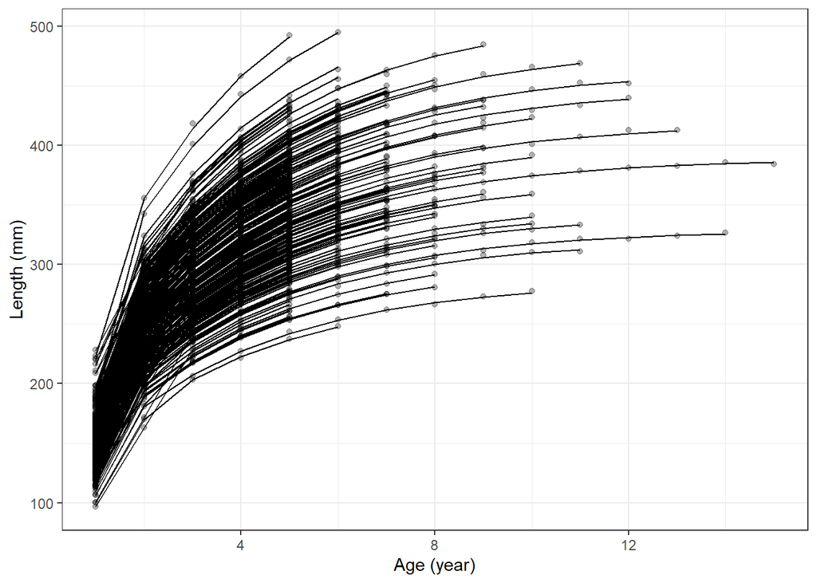

```r
fn_sim(seed = 2)[[2]]
```

Prior to the analysis, we need to add observations for age 0 and create a list of indices for the first observation of individual fish growth trajectories.

```r
# add observations (NA) for age 0
setDT(data)               # convert to datatable class
setorder(data, id, age)   # rearrange by id and age
dat.ls <- split(data, f = data$id)
dat.ls <- lapply(dat.ls, function(x){
    x0 <- x[1,]
    x0$age = 0
    x0$vt_sim = NA
    rbind(x0,x)
  })
data <- do.call("rbind", dat.ls)

# list of indices of the first observations
ids <- c(1,1+cumsum(table(data$id))) # index corresponding to the first observation of an individual fish growth trajectory
ids <- ids[-length(ids)]             # figure out where the data starts
names(ids) <- sort(unique(data$id))
```

Second, we generate the lists of 1000 random values for each parameters.

```r
set.seed(2)
# median v0 and h
v0_med <- median(data$vt_sim[data$age==1] - (data$vt_sim[data$age==2]-data$vt_sim[data$age==1]))
h_med <- median(data$vt_sim[data$age==2]-data$vt_sim[data$age==1])

# list of random values for initial parameters
ini_loga <- round(log(100),1) #fixed the slope maturing probability at 100
list_tmat <- runif(1000, min = 1, max = 3) #Tmat 1-3
list_v0 <- runif(1000, min = v0_med - 0.5*v0_med, max = v0_med + 0.5*v0_med)
list_h <- runif(1000, min = h_med - 0.5*h_med, max = h_med + 0.5*h_med)
list_alpha <- runif(1000, min = 0.3, max = 0.7) #assume alpha within 0.3-0.7
list_chi <- runif(1000, min = 0.3, max = 0.7) #assume chi within 0.3-0.7
# prec <- 2 - high value for sigma (numerically more stable)
list_sd <- runif(1000, min = 0.1, max = 1) # assume sd within 0-1
list_rho <- runif(1000, min = -1, max = 1) # rho -1 to 1
```

Finally, we fit the model. Prior to fitting the model, we create the list containing the data.

```r
# list containing data
n_states = 2 # number of states: juvenile vs adult
dat <- list(
    "n_states" = n_states,
    "growth_first_idx" = ids,                                     # integer vector
    "beta_linear_covs" = cbind(rep(1,nrow(data)), data$age),      # matrix with covariates for the transition state (intercept = 1 and age)
    "age" = c(data$age),                                          # vector of age covariates (for the observations)
    "len" = matrix(data$vt_sim, ncol = 1),                        # vector of observations
    #"keyVar" = (numeric(n_states)),                              # initial state probabilities (can be estimated in the model, but here we assume fish are immature at the start of their life)
    "id" = as.numeric(as.factor(data$id)) - 1                     # minus 1 because indexing in C++ starts at 0
  )

# list containing initial parameters
```

```r
# dataframe and lists to store model fitting results
df_nll <- tibble()
list_opt <- list()
list_obj <- list()

# for loop to iterate the model fitting, the loop stops after fitting 10 the model 10 times
for(j in 1:100) {
    print(paste("processing random par", j, sep = " "))

    # list of initial parameters, randomly selected from the 1000-value lists
    par <- list(
      "log_beta_linear_pars" = matrix(c(ini_loga, log(sample(list_tmat[j],1))),nrow = 2),         # parameter matrix correpsonding to the transition probability from juvenile to adult (slope and Tmat)
      "v0"= sample(list_v0[j],1),
      "log_h" = log(sample(list_h[j],1)),
      "logit_alpha" = logit(sample(list_alpha[j],1)),
      "logit_chi" = logit(sample(list_chi[j],1)),
      "log_prec" = log(2),  # high value for sigma (numerically more stable)
      "log_sd_h" = log(sample(list_sd[j],1)),
      "log_sd_tmat" = log(sample(list_sd[j],1)),
      "trans_rho" = c(itrans_rev(sample(list_rho[j],1))), #rho_h_tmat, rho_h_alpha
      "mu_random" = matrix(0, nrow = 2, ncol = length(unique(dat$id)))  # row 1 = log_h, row 2 = log_Tmat
    )

    # create fitting object with data, initial parameters, indication of random effects, and model
    obj <- TMB::MakeADFun(dat,
                          par,
                          random = "mu_random",
                          map = list("log_beta_linear_pars" = factor(c(NA, 0))), #fix loga = log(100)
                          DLL="hmm_quince_model")

    # next/break when there is error in opt
    if ( is.null(tryCatch({
      # fitting using nlminb
      opt <- nlminb(obj$par, obj$fn, obj$gr,
                      control = list(iter.max = 10000, eval.max = 10000))

      #opt <- do.call("optim",obj)

      m_name <- paste("rep", j, sep = "_")

      # save fitting info
      list_opt[[m_name]] <- opt
      list_obj[[m_name]] <- obj

      df_nll_temp <- tibble(
        m_name = m_name,
        nll = opt$objective,
        convergence = opt$convergence,
        message = opt$message)
      df_nll <- bind_rows(df_nll, df_nll_temp)

    }, error = function(e){}))) {
      print("error");
      next
    }

    # end the loop after 10 fitting times
    if (nrow(df_nll) == 10) {
      print("run 10 times, stop")
      break
    }
}

# save results
write_rds(df_nll, "supplement_df_nll.rds")
write_rds(list_opt, "supplement_list_opt.rds")
write_rds(list_obj, "supplement_list_obj.rds")
```

# 4. Report

The best fit (converged fit with the lowest negative log-likelihood) was rep_6.

```r
df_nll %>% arrange(nll)
```

```
## # A tibble: 10 × 4
##    m_name   nll convergence message
##    <chr>  <dbl>       <int> <chr>
##  1 rep_3  4042.           1 false convergence (8)
##  2 rep_6  4050.           0 relative convergence (4)
##  3 rep_1  4065.           1 false convergence (8)
##  4 rep_4  4105.           1 false convergence (8)
##  5 rep_2  4128.           0 relative convergence (4)
##  6 rep_10 4601.           0 relative convergence (4)
##  7 rep_5  5564.           1 false convergence (8)
##  8 rep_7  8229.           1 false convergence (8)
##  9 rep_8  8687.           1 false convergence (8)
## 10 rep_11 8882.           1 false convergence (8)
```

```r
tibble(par_name = c("Tmat", "v0", "h", "alpha", "chi", "prec", "sd_h", "sd_Tmat", "rho_h_Tmat"),
       par_est = transpar(list_opt[["rep_6"]]),
       par_sim = c(1.8, 30, 115, 0.35, 0.75, 300, 0.2, 0.2, -0.7),
       bias = (par_est-par_sim)/par_sim*100)  %>%
    mutate_if(is.numeric, round, 2)
```

```
## # A tibble: 9 × 4
##   par_name   par_est par_sim  bias
##   <chr>        <dbl>   <dbl> <dbl>
## 1 Tmat          1.77    1.8  -1.74
## 2 v0           29.6    30    -1.16
## 3 h           119.    115     3.21
## 4 alpha         0.35    0.35 -0.09
## 5 chi           0.75    0.75  0
## 6 prec        295.    300    -1.55
## 7 sd_h          0.21    0.2   2.66
## 8 sd_Tmat       0.21    0.2   5.32
## 9 rho_h_Tmat   -0.71   -0.7   1.48
```

The standard deviation of the estimated parameters can be obtained using the *sdreport()* function.

```r
sdrep <- TMB::sdreport(list_obj[["rep_6"]]) #4bc rep_309, 7a rep_350, 8ab rep_967
```

[output not shown]

[output cut: 46 more lines]

[output not shown]

```r
sdrep_sum <- summary(sdrep)
sdrep_sum <- as.data.frame(sdrep_sum) %>% mutate(pars = row.names(sdrep_sum))
```

```r
sdrep_sum %>% filter(pars %in% c("Tmat_mean", "v0", "h_mean", "alpha", "chi", "prec", "sd_h", "sd_tmat", "rho_h_tmat")) %>%
    unique() %>%
    select(Estimate, `Std. Error`) %>%
    mutate_if(is.numeric, round, 2)
```

```
##            Estimate Std. Error
## v0            29.65       0.05
## h_mean       118.69       1.54
## Tmat_mean      1.77       0.02
## alpha          0.35       0.00
## chi            0.75       0.00
## sd_h           0.21       0.01
## sd_tmat        0.21       0.01
## rho_h_tmat    -0.71       0.03
## prec         295.36       6.48
```

Finally, we can examine the fit by plotting the estimated growth curves (lines) onto the data (points).

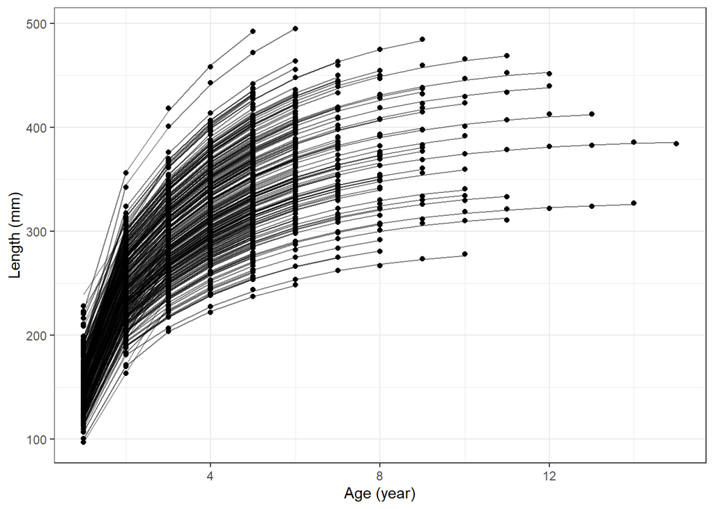

```r
#### data rep
# get report from obj
obj <- list_obj[["rep_6"]]
rep <- obj$report()

# data rep
data_rep <- data %>%
    mutate(mu_juv = rep$mu[,1],
           mu_adu = rep$mu[,2],
           mu = if_else(age <= Tmat, mu_juv, mu_adu)) %>%
    filter(age >= 1)

ggplot(data = data_rep) +
    geom_point(aes(x = age, y = vt_sim, group = id)) +
    geom_line(aes(x = age, y = mu, group = id), alpha = 0.5) +
    labs(x = "Age (year)",
         y = "Length (mm)") +
    theme_bw()
```

# 5. References

Brunel, Thomas, Bruno Ernande, Fabian M Mollet, and Adriaan D Rijnsdorp. 2013. “Estimating Age at Maturation and Energy-Based Life-History Traits from Individual Growth Trajectories with Nonlinear Mixed-Effects Models.” *Oecologia* 172: 631–43.

DATRAS. 2023. “ICES Database on Trawl Surveys.” *ICES, Copenhagen, Denmark. Https://Datras.ices.dk*.